# Thesis

Richards Zheng s270141

Generated on: Sun Jun 21 21:37:06 2020

# 1 Research questions

Main question: There is an effect of sentiment on task performance. (But we don’t know what effects what)  
**POSITIVE**  
H10: There is no effect of positive sentiment on task performance.  
H1A: The more positive sentiment used, the *higher* the task performance.  
H20: There is no effect of reading the self-repair on positive sentiment, all the participants are the same positive.  
H2A: Reading the self-repair makes the participants *less* positive.  
**NEGATIVE**  
H30: There is no effect of negative sentiment on task performance.  
H3A: The more negative sentiment used, the *lower* the task performance.  
H40: There is no effect of reading self-repair on negative sentiment, all the participants are the same negative.  
H4A: Reading the self-repair makes the participants *more* negative.  
**INVOLVED**  
H50: There is no effect of involvement on task performance.  
H5A: The more involved, the *higher* the task performance.  
H60: There is no effect of reading self-repair on involvement, all the participants are the same involved.  
H6A: Reading the self-repair makes the participants *more* involved.  
**ANGER**  
H70: There is no effect of anger on task performance.  
H7A: The more angry, the *lower* the task performance.  
H80: There is no effect of reading self-repair on anger, all the participants are the same angry.  
H8A: Reading the self-repair makes the participants *more* angry.  
**Game**  
H90: Game0 success doesn’t affect game X success.  
H9A: Game0 success makes it more likely that game X will be a success.  
*Task performance measured in games completed.

# 2 Models

POSEMO  
glmer(cbind(positive, notPositive) ~ condition + (1 + | dyad)).  
glmer(cbind(complete, timeout) ~ posemo + (1 | dyad)) <- only for baseline.  
lmer(totalscoreParticipant ~ condition + (1 | Dyad)) <- scores for positive sentiment.  
NEGEMO  
glmer(cbind(negative, notNegative) ~ condition + (1 + | dyad)).  
glmer(cbind(complete, timeout) ~ negemo + (1 | dyad)) <- only for baseline.  
lmer(totalscoreParticipant ~ condition + (1 | Dyad) <- scores for negative sentiment

# 3 Mazes data

```r
library(lme4); library(nlme); library(ggplot2); library(tidyverse); library(optimx) ;library(car)
mazes <- read.csv('mazes.csv',sep=',',dec='.')

mazes$dyad <- as.factor(mazes$dyad)
mazes$posemo <- as.integer(mazes$posemo)
mazes$negemo <- as.integer(mazes$negemo)
mazes$pronadv <- as.integer(mazes$pronadv)
mazes$anger <- as.integer(mazes$anger)
mazes$condition <- as.factor(mazes$condition)

head(mazes)
```

```
##   dyad posemo negemo pronadv anger words positive notPositive negative
## 1    1    472      0     215     0   939       12         927        0
## 2    2   1230    239     138    75  1377       23        1354        5
## 3    3    715    100      78   100  1058       22        1036        1
## 4    4    764    322      14   258  1263       15        1248        7
## 5    5   1060    316      66     0  1512       23        1489        4
## 6    6   1611    298      73   195  1190       31        1159        7
##   notNegative involved notInvolved angry notAngry condition complete timeout
## 1         939       13         926     0      939    repair       11       1
## 2        1372        6        1371     2     1375    repair        8       4
## 3        1057        3        1055     1     1056      base       12       0
## 4        1256        1        1262     5     1258    repair       10       2
## 5        1508        2        1510     0     1512    repair       11       1
## 6        1183        4        1186     4     1186    repair        9       3
```

```r
str(mazes)
```

```
## 'data.frame':    59 obs. of  17 variables:
##  $ dyad       : Factor w/ 59 levels "1","2","3","4",..: 1 2 3 4 5 6 7 8 9 10 ...
##  $ posemo     : int  472 1230 715 764 1060 1611 1807 2762 3145 1504 ...
##  $ negemo     : int  0 239 100 322 316 298 33 233 583 276 ...
##  $ pronadv    : int  215 138 78 14 66 73 25 586 0 33 ...
##  $ anger      : int  0 75 100 258 0 195 33 33 583 256 ...
##  $ words      : int  939 1377 1058 1263 1512 1190 1323 1479 1630 1118 ...
##  $ positive   : int  12 23 22 15 23 31 37 51 45 23 ...
##  $ notPositive: int  927 1354 1036 1248 1489 1159 1286 1428 1585 1095 ...
##  $ negative   : int  0 5 1 7 4 7 1 4 7 7 ...
##  $ notNegative: int  939 1372 1057 1256 1508 1183 1322 1475 1623 1111 ...
##  $ involved   : int  13 6 3 1 2 4 1 13 0 2 ...
##  $ notInvolved: int  926 1371 1055 1262 1510 1186 1322 1466 1630 1116 ...
##  $ angry      : int  0 2 1 5 0 4 1 1 7 6 ...
##  $ notAngry   : int  939 1375 1056 1258 1512 1186 1322 1478 1623 1112 ...
##  $ condition  : Factor w/ 2 levels "base","repair": 2 2 1 2 2 2 2 2 2 2 ...
##  $ complete   : int  11 8 12 10 11 9 12 8 10 11 ...
##  $ timeout    : int  1 4 0 2 1 3 0 4 2 1 ...
```

# 4 Info mazegame

```r
base <- mazes[mazes$condition == "base",]
repair <- mazes[mazes$condition == "repair",]
mean(base$complete)
```

```
## [1] 10.84
```

```r
mean(repair$complete)
```

```
## [1] 9.588235
```

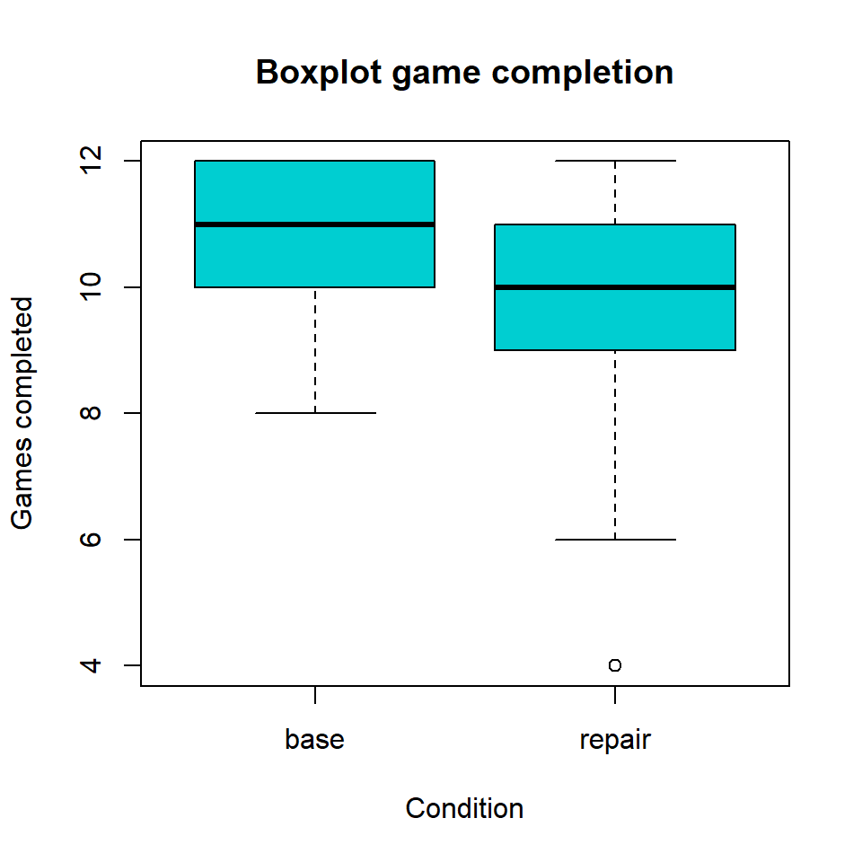

```r
boxplot(mazes$complete ~ mazes$condition, main = "Boxplot game completion", xlab = "Condition", ylab = "Games completed", col = "darkturquoise")
```

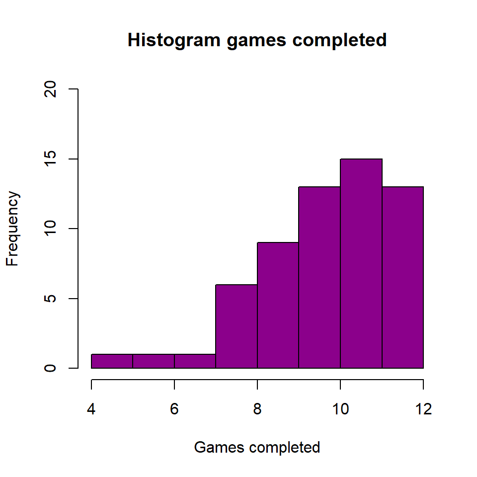

```r
hist(mazes$complete, main = "Histogram games completed", xlab = "Games completed", ylab = "Frequency", col = "darkmagenta", ylim = c(0,20))
```

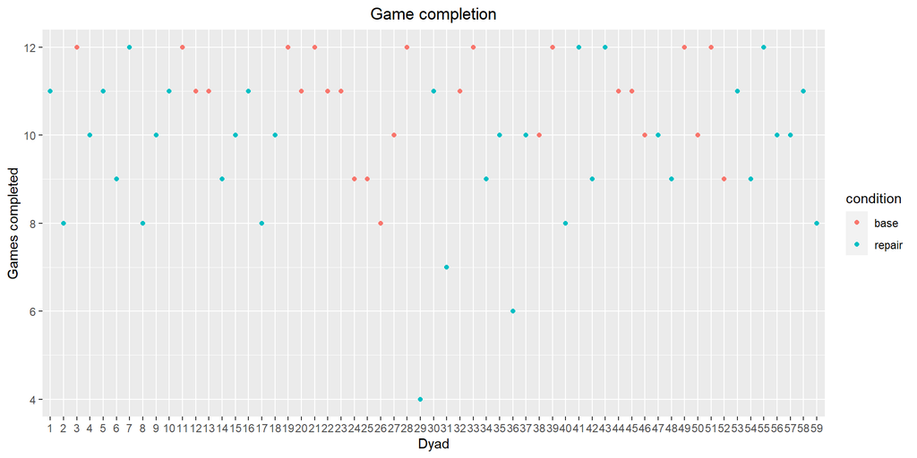

```r
ggplot(mazes, aes(dyad, y = complete, colour = condition)) + geom_point() + ylab("Games completed") + xlab("Dyad") + ggtitle("Game completion") + theme(plot.title = element_text(hjust = 0.5))
```

# 5 Assumptions binomial logistic regression

## 5.1 Observations should be independent

Yes

## 5.2 The relationships between the logit and the quantitative predictors are linear

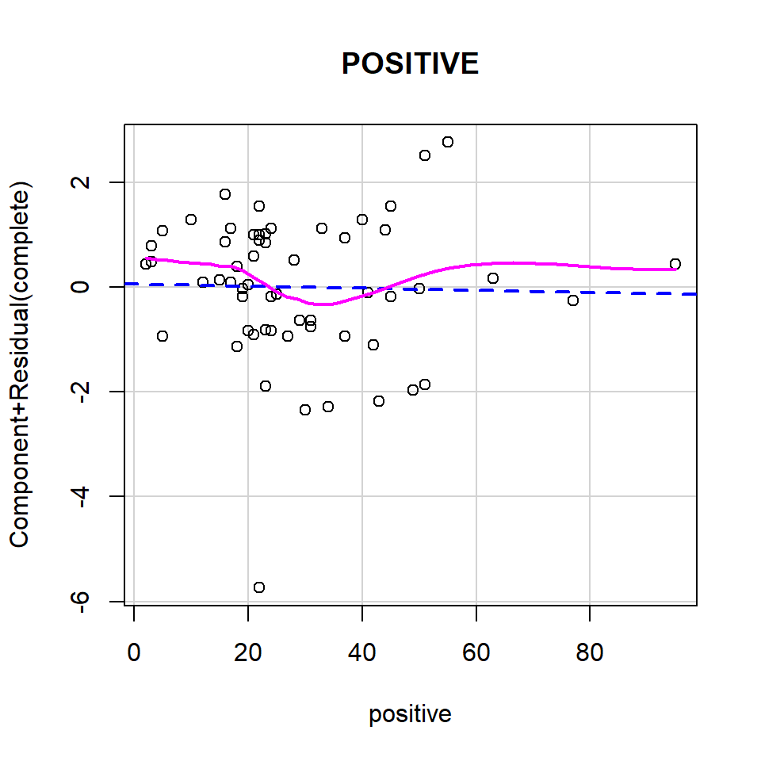

```r
m <- lm(complete ~ positive + negative + involved + angry, data = mazes)
#summary(m)
crPlot(m, var = "positive", main = "POSITIVE")
```

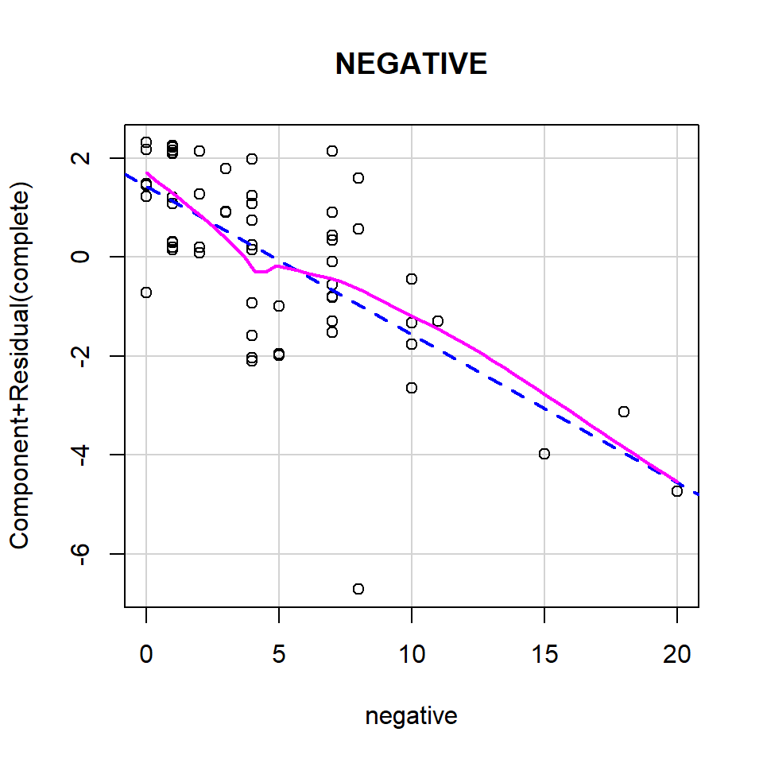

```r
crPlot(m, var = "negative", main = "NEGATIVE")
```

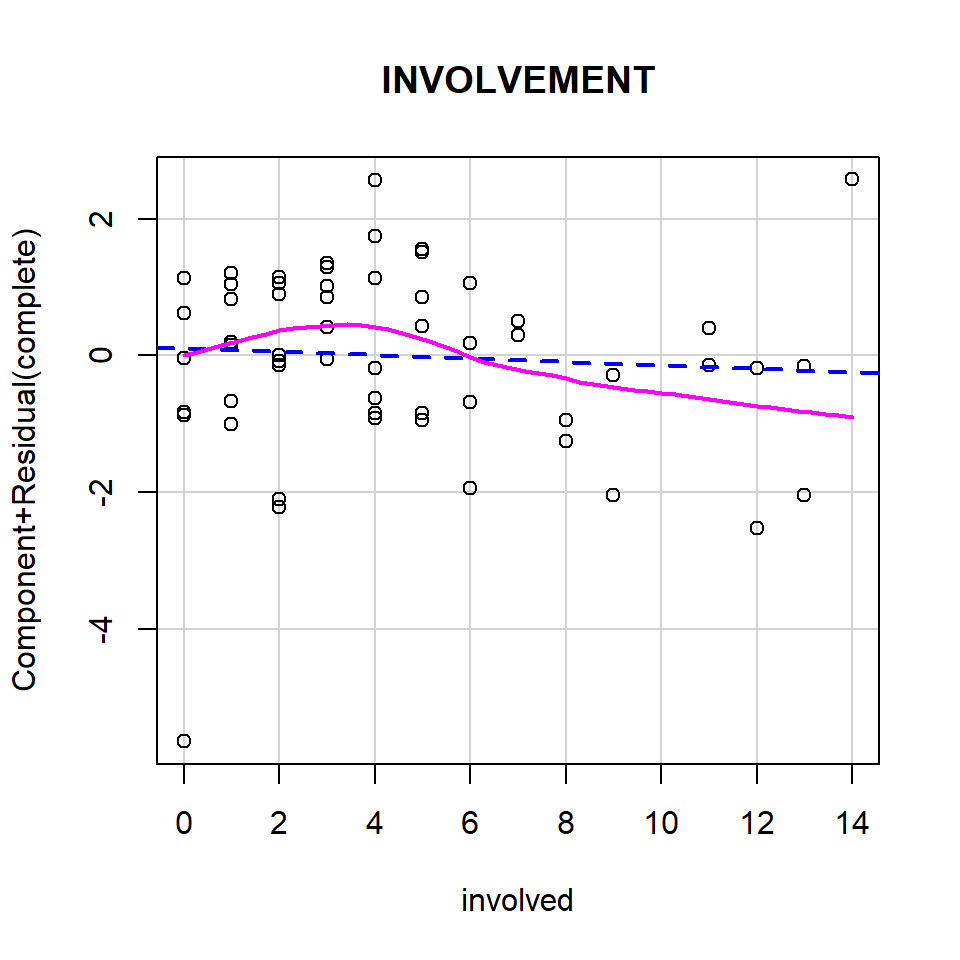

```r
crPlot(m, var = "involved", main = "INVOLVEMENT")
```

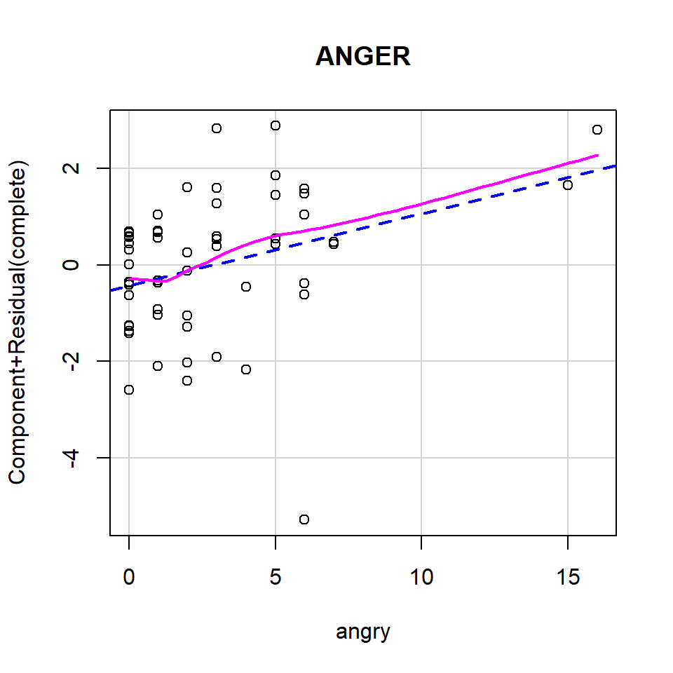

```r
crPlot(m, var = "angry", main = "ANGER")
```

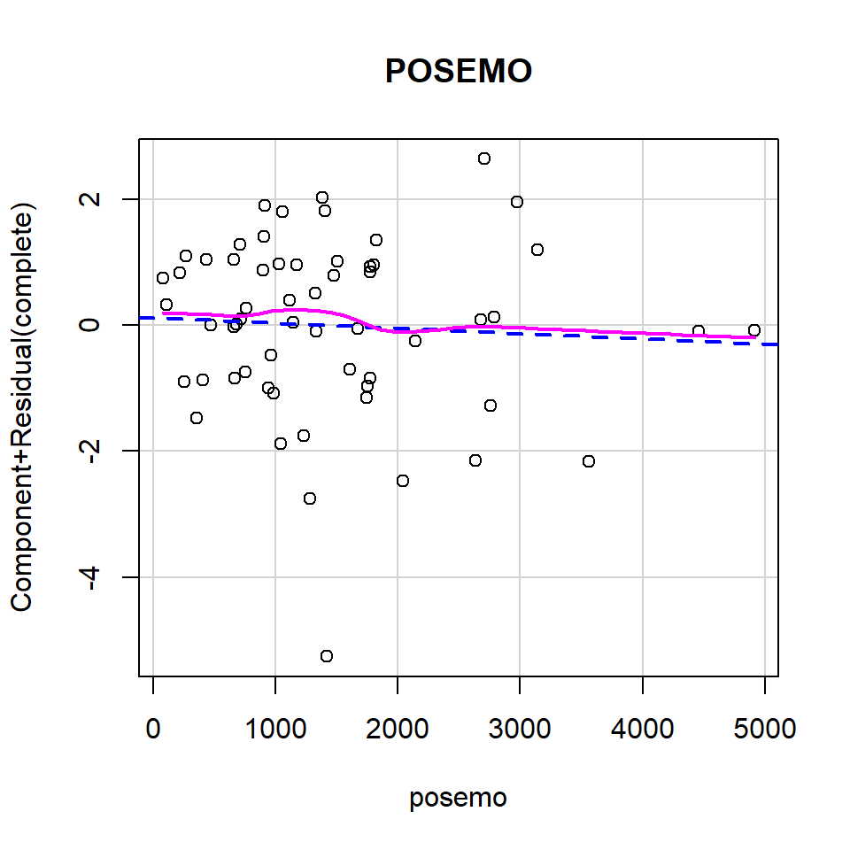

```r
m2 <- lm(complete ~ posemo + negemo + pronadv + anger, data = mazes)
#summary(m)
crPlot(m2, var = "posemo", main = "POSEMO")
```

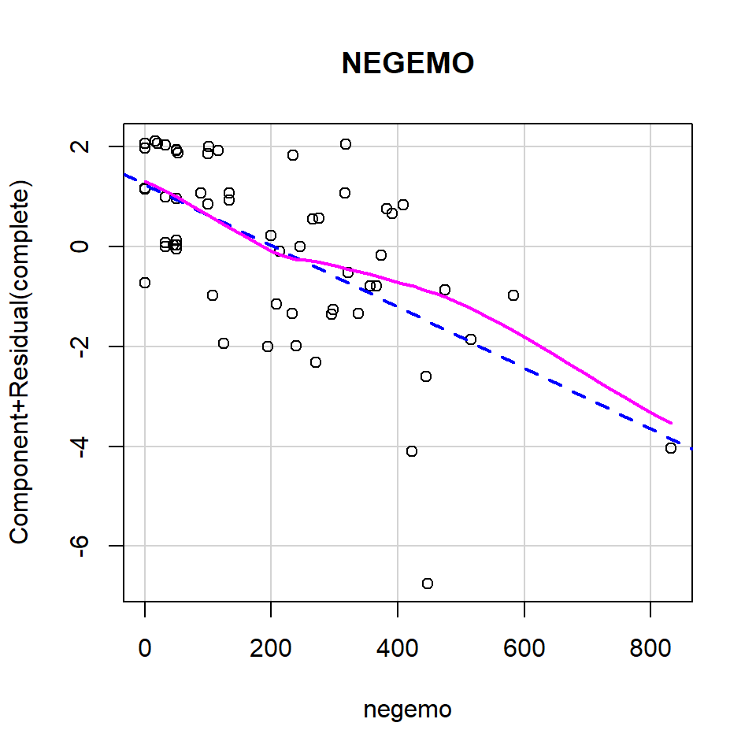

```r
crPlot(m2, var = "negemo", main = "NEGEMO")
```

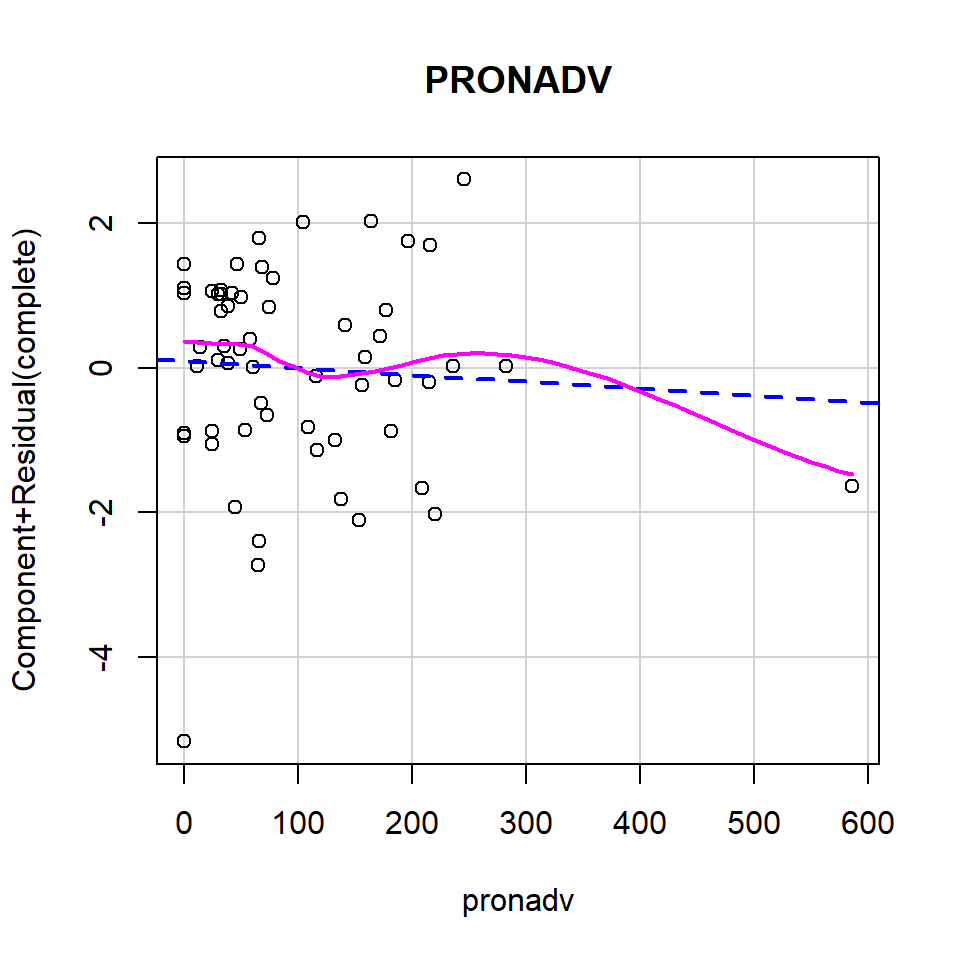

```r
crPlot(m2, var = "pronadv", main = "PRONADV")
```

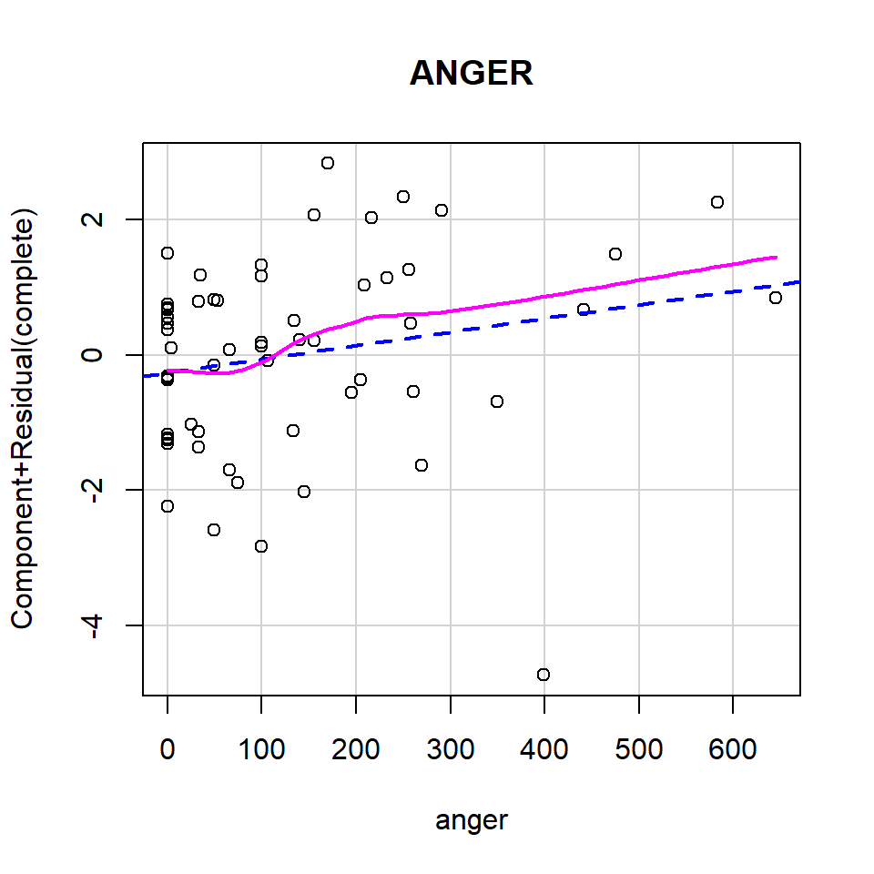

```r
crPlot(m2, var = "anger", main = "ANGER")
```

## 5.3 There is no multicollinearity

```r
vif(m)
```

```
## positive negative involved    angry
## 1.521010 5.194134 1.170537 4.577774
```

```r
vif(m2)
```

```
##   posemo   negemo  pronadv    anger
## 1.268600 6.507418 1.197775 6.037511
```

Only for negativity the vif score is bigger than 5.

Negemo and anger also bigger than 5

# 6 Graphs

## 6.1 Positive

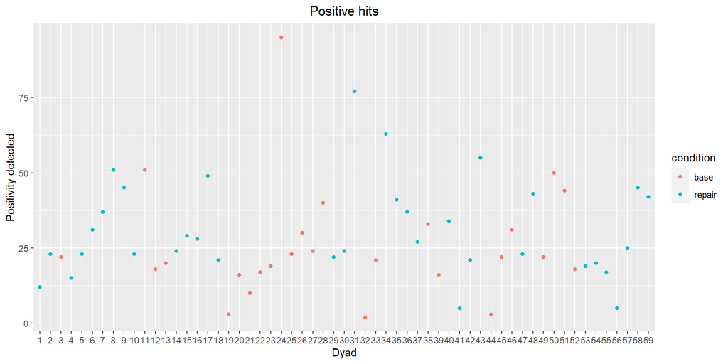

```r
ggplot(mazes, aes(dyad, y = positive, colour = condition)) + geom_point() + ylab("Positivity detected") + xlab("Dyad") + ggtitle("Positive hits") + theme(plot.title = element_text(hjust = 0.5))
```

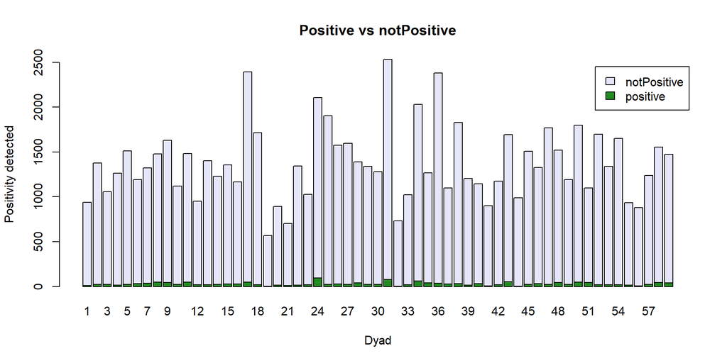

```r
positivity <- data.frame(dyad = mazes$dyad, positive = mazes$positive, notPositive = mazes$notPositive)
barplot(t(as.matrix(positivity[, 2:3])), names.arg = positivity$dyad, legend.text = TRUE, col = c("forestgreen", "lavender"), xlab = "Dyad", ylab = "Positivity detected", main = "Positive vs notPositive")
```

## 6.2 Negative

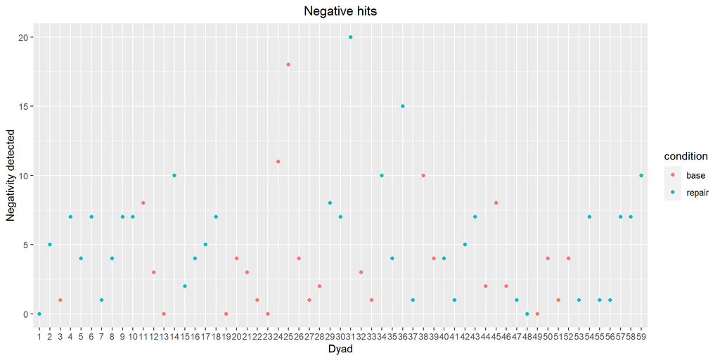

```r
ggplot(mazes, aes(dyad, y = negative, colour = condition)) + geom_point() + ylab("Negativity detected") + xlab("Dyad") + ggtitle("Negative hits") + theme(plot.title = element_text(hjust = 0.5))
```

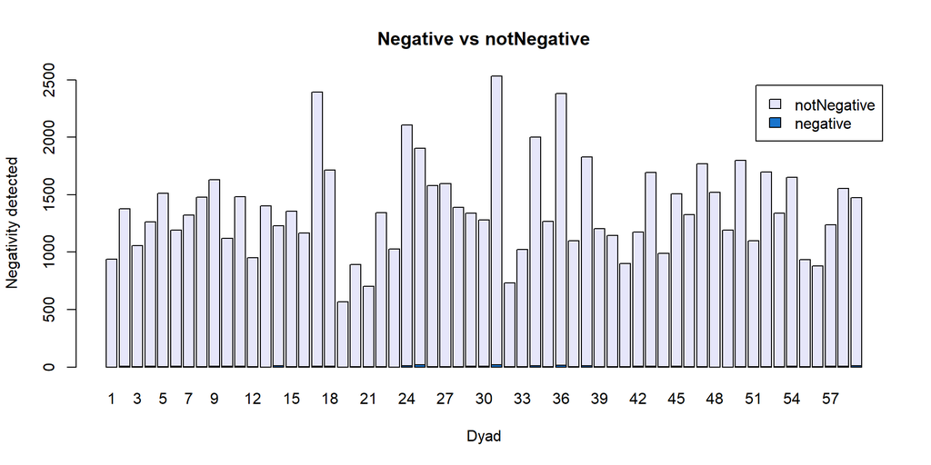

```r
negativity <- data.frame(dyad = mazes$dyad, negative = mazes$negative, notNegative = mazes$notNegative)
barplot(t(as.matrix(negativity[, 2:3])), names.arg = negativity$dyad, legend.text = TRUE, col = c("dodgerblue3", "lavender"), xlab = "Dyad", ylab = "Negativity detected", main = "Negative vs notNegative")
```

## 6.3 Involvement

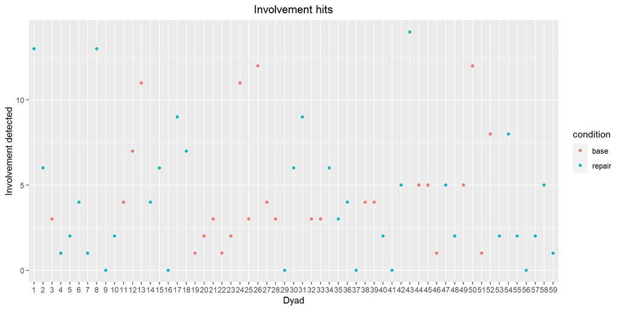

```r
ggplot(mazes, aes(dyad, y = involved, colour = condition)) + geom_point() + ylab("Involvement detected") + xlab("Dyad") + ggtitle("Involvement hits") + theme(plot.title = element_text(hjust = 0.5))
```

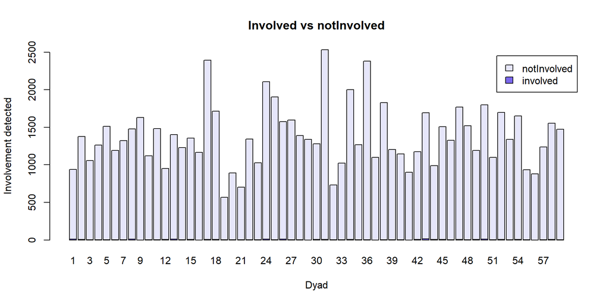

```r
involved <- data.frame(dyad = mazes$dyad, involved = mazes$involved, notInvolved = mazes$notInvolved)
barplot(t(as.matrix(involved[, 2:3])), names.arg = involved$dyad, legend.text = TRUE, col = c("mediumslateblue", "lavender"), xlab = "Dyad", ylab = "Involvement detected", main = "Involved vs notInvolved")
```

## 6.4 Anger

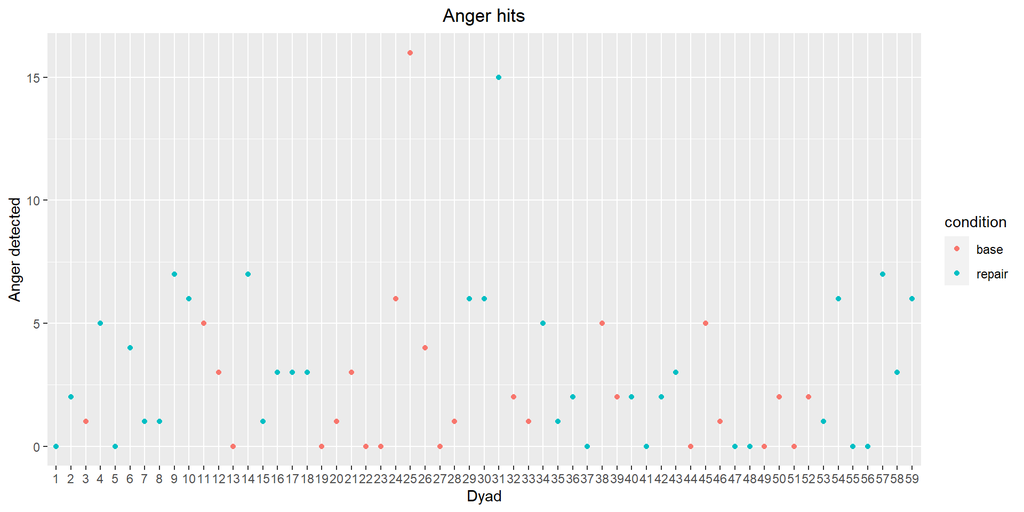

```r
ggplot(mazes, aes(dyad, y = angry, colour = condition)) + geom_point() + ylab("Anger detected") + xlab("Dyad") + ggtitle("Anger hits") + theme(plot.title = element_text(hjust = 0.5))
```

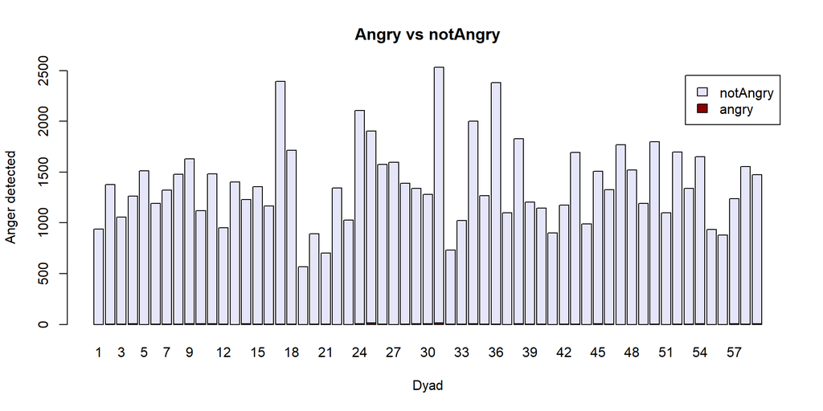

```r
angry <- data.frame(dyad = mazes$dyad, angry = mazes$angry, notAngry = mazes$notAngry)
barplot(t(as.matrix(angry[, 2:3])), names.arg = angry$dyad, legend.text = TRUE, col = c("darkred", "lavender"), xlab = "Dyad", ylab = "Anger detected", main = "Angry vs notAngry")
```

# 7 New graphs

## 7.1 Positive

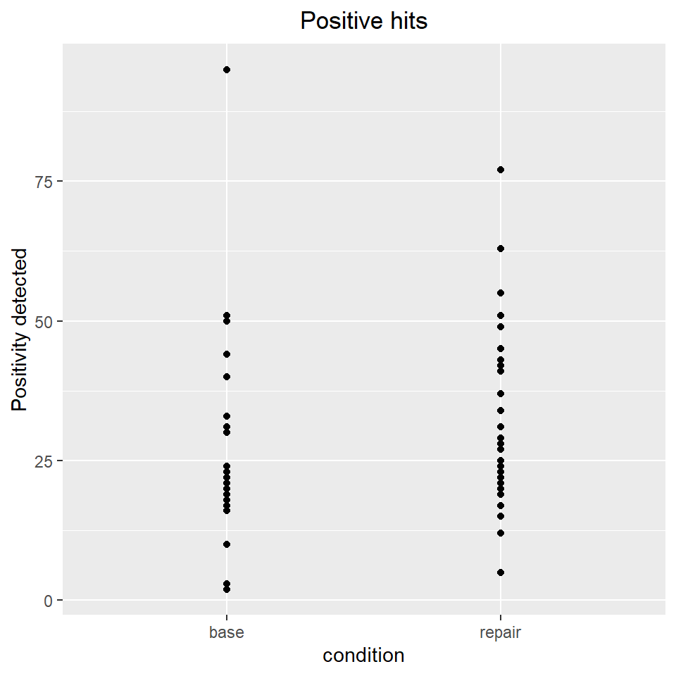

```r
ggplot(mazes, aes(dyad, y = positive, x = condition)) + geom_point() + ylab("Positivity detected") + xlab("condition") + ggtitle("Positive hits") + theme(plot.title = element_text(hjust = 0.5))
```

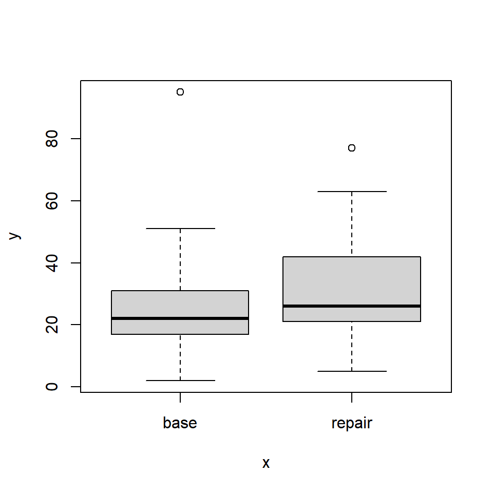

```r
plot(mazes$condition, mazes$positive)
```

## 7.2 Negative

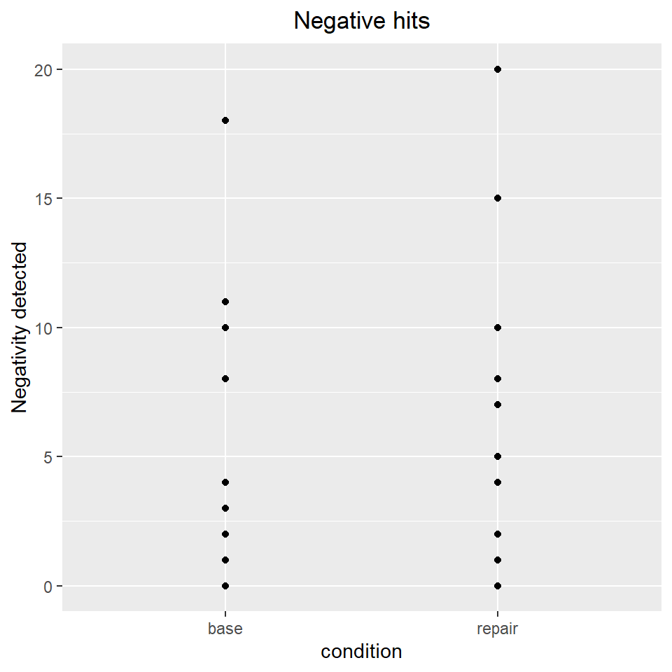

```r
ggplot(mazes, aes(dyad, y =  negative, x = condition)) + geom_point() + ylab("Negativity detected") + xlab("condition") + ggtitle("Negative hits") + theme(plot.title = element_text(hjust = 0.5))
```

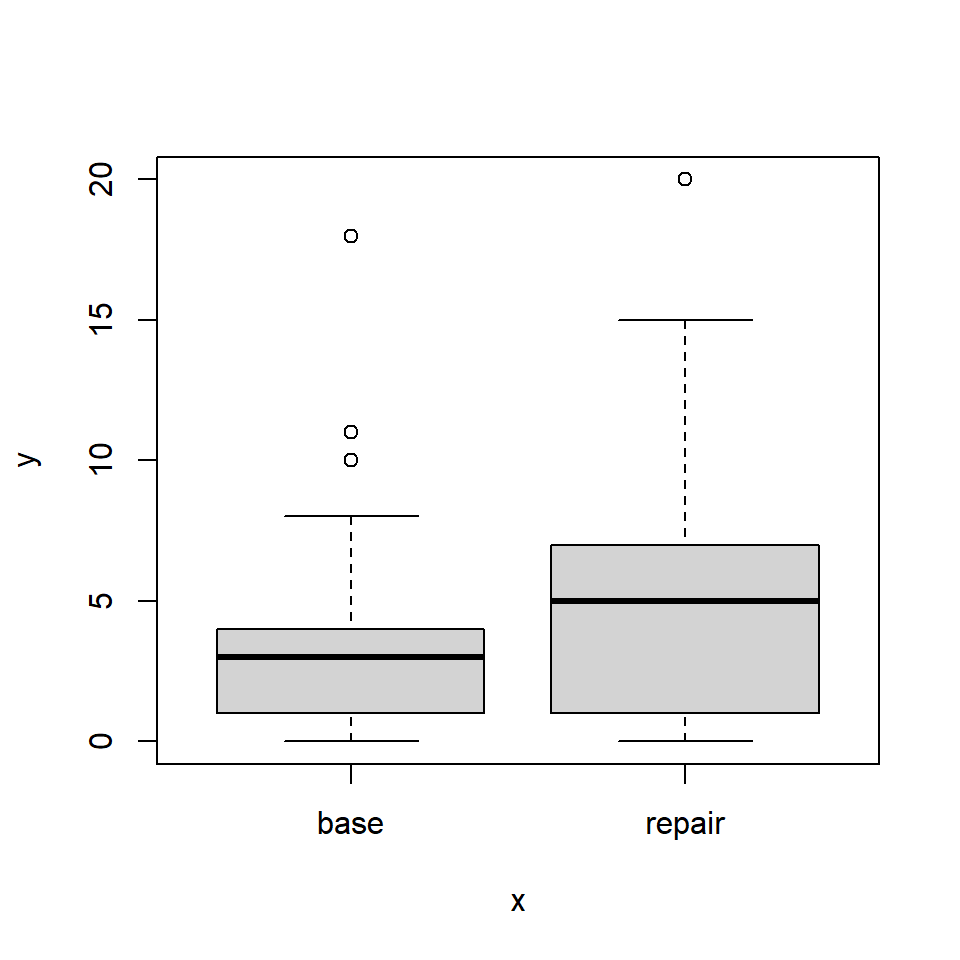

```r
plot(mazes$condition, mazes$negative)
```

```r
mazes$negative
```

```
##  [1]  0  5  1  7  4  7  1  4  7  7  8  3  0 10  2  4  5  7  0  4  3  1  0 11 18
## [26]  4  1  2  8  7 20  3  1 10  4 15  1 10  4  4  1  5  7  2  8  2  1  0  0  4
## [51]  1  4  1  7  1  1  7  7 10
```